# A multilayer fitting model

One of the main tools in `easyreflectometry` is the assemblies library. This allows the user to define their model, using specific parameters for their system of interest (if it is included in the assemblies library). These assemblies will impose necessary constraints and computational efficiencies based on the assembly that is used.

In this tutorial, we will look at one of these assemblies, that of a `RepeatingMultilayer` (documented here). This tutorial is based on an example from the [BornAgain](https://www.bornagainproject.org) documentation looking at [specular reflectivity analysis](https://www.bornagainproject.org/m/py/fitting/extended/fit-specular-data/). Before performing analysis, we should import the packages that we need.

First configure matplotlib to place figures in notebook and import needed modules. Note that the plot function needs installation of `plopp` seperately or installation of `easyreflectometry[dev]`

```python
%matplotlib inline
```

%matplotlib inline

```python
import numpy as np
import pooch
import refl1d
import scipp as sc

import easyreflectometry
from easyreflectometry.calculators import CalculatorFactory
from easyreflectometry.data import load
from easyreflectometry.fitting import MultiFitter
from easyreflectometry.model import Model
from easyreflectometry.model import PercentageFwhm
from easyreflectometry.plot import plot
from easyreflectometry.sample import Layer
from easyreflectometry.sample import Material
from easyreflectometry.sample import Multilayer
from easyreflectometry.sample import RepeatingMultilayer
from easyreflectometry.sample import Sample
```

import numpy as np import pooch import refl1d import scipp as sc import easyreflectometry from easyreflectometry.calculators import CalculatorFactory from easyreflectometry.data import load from easyreflectometry.fitting import MultiFitter from easyreflectometry.model import Model from easyreflectometry.model import PercentageFwhm from easyreflectometry.plot import plot from easyreflectometry.sample import Layer from easyreflectometry.sample import Material from easyreflectometry.sample import Multilayer from easyreflectometry.sample import RepeatingMultilayer from easyreflectometry.sample import Sample

As mentioned in the previous tutorial, we share the version of the software packages we will use.

```python
print(f'numpy: {np.__version__}')
print(f'scipp: {sc.__version__}')
print(f'easyreflectometry: {easyreflectometry.__version__}')
print(f'Refl1D: {refl1d.__version__}')
```

print(f'numpy: {np.__version__}') print(f'scipp: {sc.__version__}') print(f'easyreflectometry: {easyreflectometry.__version__}') print(f'Refl1D: {refl1d.__version__}')

```
numpy: 2.4.4
scipp: 26.3.1
easyreflectometry: 999.0.0
Refl1D: 1.0.1
```

## Reading in experimental data

The data that we will investigate in this tutorial was generated with [GenX](https://aglavic.github.io/genx/) and is stored in an `.ort` [format file](https://github.com/reflectivity/file_format/blob/master/specification.md). We use `pooch` to fetch the file from the repository.

```python
file_path = pooch.retrieve(
    # Fetch test data from the easyscience/reflectometry data repository
    url='https://raw.githubusercontent.com/easyscience/reflectometry/master/data/repeating_layers.ort',
    known_hash='a5ffca9fd24f1d362266251723aec7ce9f34f123e39a38dfc4d829c758e6bf90',
)
data = load(file_path)
```

file_path = pooch.retrieve( # Fetch test data from the easyscience/reflectometry data repository url='https://raw.githubusercontent.com/easyscience/reflectometry/master/data/repeating_layers.ort', known_hash='a5ffca9fd24f1d362266251723aec7ce9f34f123e39a38dfc4d829c758e6bf90', ) data = load(file_path)

```
Downloading data from 'https://raw.githubusercontent.com/easyscience/reflectometry/master/data/repeating_layers.ort' to file '/home/runner/.cache/pooch/acff3b23f6d19849a1e42df551bca7f5-repeating_layers.ort'.
```

This data is very featureful, with many fringes present (arising from the multilayer structure)

```python
plot(data)
```

plot(data)

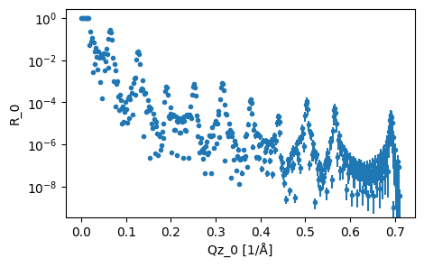

## Building our model

The system that was used to produce the data shown above is based on a silicon subphase, with a repeating multilayer of nickel and titanium grown upon it. Typcially, under experimental conditions, the producer of the sample will know how many repeats there will be of the multilayer system (as these are grown using some vapour disposition or sputtering method that the producer controls). We show the model that will be used graphically below.

[figure not shown]

A slab model description of the repeating multilayer, showing the four layers of vacuum, titanium, nickel and silicon, with the titanium/nickel layers being repeated 10 times.

To construct such a layer structure, first we create each of the materials and associated layers

```python
vacuum = Material(sld=0, isld=0, name='Vacuum')
ti = Material(sld=-1.9493, isld=0, name='Ti')
ni = Material(sld=9.4245, isld=0, name='Ni')
si = Material(sld=2.0704, isld=0, name='Si')
```

vacuum = Material(sld=0, isld=0, name='Vacuum') ti = Material(sld=-1.9493, isld=0, name='Ti') ni = Material(sld=9.4245, isld=0, name='Ni') si = Material(sld=2.0704, isld=0, name='Si')

```python
superphase = Layer(material=vacuum, thickness=0, roughness=0, name='Vacuum Superphase')
ti_layer = Layer(material=ti, thickness=40, roughness=0, name='Ti Layer')
ni_layer = Layer(material=ni, thickness=70, roughness=0, name='Ni Layer')
subphase = Layer(material=si, thickness=0, roughness=0, name='Si Subphase')
```

superphase = Layer(material=vacuum, thickness=0, roughness=0, name='Vacuum Superphase') ti_layer = Layer(material=ti, thickness=40, roughness=0, name='Ti Layer') ni_layer = Layer(material=ni, thickness=70, roughness=0, name='Ni Layer') subphase = Layer(material=si, thickness=0, roughness=0, name='Si Subphase')

Then, to produce the repeating multilayer, we use the `RepeatingMultilayer` assembly type. This can be constructed in a range of different ways, however here we pass a list of `Layer` type objects and a number of repetitions.

```python
rep_multilayer = RepeatingMultilayer([ti_layer, ni_layer], repetitions=10, name='NiTi Multilayer')
rep_multilayer
```

rep_multilayer = RepeatingMultilayer([ti_layer, ni_layer], repetitions=10, name='NiTi Multilayer') rep_multilayer

```
NiTi Multilayer:
  Ti Layer/Ni Layer:
  - Ti Layer:
      material:
        Ti:
          sld: -1.949e-6 1/Å^2
          isld: 0.000e-6 1/Å^2
      thickness: 40.000 Å
      roughness: 0.000 Å
  - Ni Layer:
      material:
        Ni:
          sld: 9.425e-6 1/Å^2
          isld: 0.000e-6 1/Å^2
      thickness: 70.000 Å
      roughness: 0.000 Å
  repetitions: 10.0
```

From these objects, we can construct our structure and combine this with a scaling, background and resolution (since this data is simulated there is no background or resolution smearing).

```python
resolution_function = PercentageFwhm(0)
sample = Sample(Multilayer(superphase), rep_multilayer, Multilayer(subphase), name='Multilayer Structure')
model = Model(sample=sample, scale=1, background=0, resolution_function=resolution_function, name='Multilayer Model')
```

resolution_function = PercentageFwhm(0) sample = Sample(Multilayer(superphase), rep_multilayer, Multilayer(subphase), name='Multilayer Structure') model = Model(sample=sample, scale=1, background=0, resolution_function=resolution_function, name='Multilayer Model')

```python
ti_layer.thickness.min = 10
ti_layer.thickness.max = 60
```

ti_layer.thickness.min = 10 ti_layer.thickness.max = 60

## Choosing our calculation engine

In the previous tutorial, we used the default [refnx](https://refnx.readthedocs.io/) engine for our analysis. Here, we will change our engine to be [*Refl1D*](https://refl1d.readthedocs.io/en/latest/). This is achieved with the `interface.switch('refl1d')` method below.

```python
interface = CalculatorFactory()
interface.switch('refl1d')
model.interface = interface
print(interface.current_interface.name)
```

interface = CalculatorFactory() interface.switch('refl1d') model.interface = interface print(interface.current_interface.name)

```
refl1d
```

## Performing an optimisation

```python
fitter = MultiFitter(model)
# fitter.switch_minimizer(AvailableMinimizers.LMFit_differential_evolution)
analysed = fitter.fit(data)
analysed
```

fitter = MultiFitter(model) # fitter.switch_minimizer(AvailableMinimizers.LMFit_differential_evolution) analysed = fitter.fit(data) analysed

```
CollectionBase is deprecated and will be removed in a future version. Please migrate to ModelBase or EasyList.
```

```
Invalid Input Parameters. I.e. more variables than data points given, tolerance < 0.0, or no data provided. Could not estimate error-bars.
```

scipp.DataGroup

(Qz_0: 400, z_0: 11201)

- data

  dict

  ()

  {'R_0': <scipp.Variable> (Qz_0: 400) float64 <no unit> [1, 1, ..., 8....

- coords

  dict

  ()

  {'Qz_0': <scipp.Variable> (Qz_0: 400) float64 [1/Å] [0.000712093, ...

- attrs

  dict

  ()

  {'R_0': {'orso_header': <scipp.Variable> () PyObject <no unit> {'data_...

- R_0_model

  scipp

  Variable

  (Qz_0: 400)

  float64

  𝟙

  1.000, 1.000, ..., 4.405e-09, 2.160e-08

- SLD_0

  scipp

  Variable

  (z_0: 11201)

  float64

  1/Å^2

  8.882e-22, 8.882e-22, ..., 2.070e-06, 2.070e-06

- objective_chi2

  float

  ()

  11704590823.124392

- objective_reduced_chi

  float

  ()

  29261477.057810977

- classical_chi2

  float

  ()

  11704590823.124392

- classical_reduced_chi

  float

  ()

  29261477.057810977

- reduced_chi

  float

  ()

  29261477.057810977

- success

  bool

  ()

  False

We can visualise the analysed model and SLD profile with the `plot` function.

```python
plot(analysed)
```

plot(analysed)

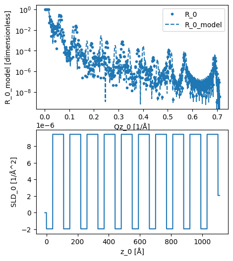

```python
ti_layer.thickness
```

ti_layer.thickness

```
<Parameter 'thickness': 40.0000 Å (fixed), bounds=[10.0:60.0]>
```